# MATP-4910 COVID-Twitter Final Project Notebook

## 4.2 Problem 2

How are we going to compare and evaluate the performance of VADER and BERT? In other words, this issue revolves around finding a common metric to compare the performance of the two models

### 4.2.1 Methods

In order compare the two methods, the testing set was used to comapre the performance of the two models. The testing set was created with the same seed for both models. Since VADER requires that classification to be done by manual thresholding, multiple thresholds were chosen to evaluate performance at different points.

### 4.2.2 Results

```python
import sys
sys.path.append('../sentiment')
from comparison import runTests, classify
from sklearn.metrics import precision_recall_fscore_support as score
import matplotlib.pyplot as plt

thresholds = [0.05, 0.1, 0.15, 0.2, 0.25, 0.3, 0.35, 0.4, 0.45]
actual = test_labels.to_numpy()
accuracies = []
for threshold in thresholds:
  print(f'Threshold: {threshold}')
  predictions = classify(test_text, threshold)

  # calculate accuracy
  test_acc = np.sum(predictions == actual) / len(actual)
  accuracies.append(test_acc)
  print(f'Accuracy: {test_acc:.2f}')

  # plot confusion matrix
  y_actu = pd.Series(actual, name='Actual')
  y_pred = pd.Series(predictions, name='Predicted')
  df_confusion = pd.crosstab(y_actu, y_pred)

  print(df_confusion)

# plot metrics on the data
```

```
## Threshold: 0.05
## Accuracy: 0.54
## Predicted     0     1     2
## Actual
## 0          1381   331   620
## 1          1220  2131  2219
## 2           994  1592  4734
## Threshold: 0.1
## Accuracy: 0.54
## Predicted     0     1     2
## Actual
## 0          1337   405   590
## 1          1168  2267  2135
## 2           921  1758  4641
## Threshold: 0.15
## Accuracy: 0.55
## Predicted     0     1     2
## Actual
## 0          1309   467   556
## 1          1097  2418  2055
## 2           862  1880  4578
## Threshold: 0.2
## Accuracy: 0.54
## Predicted     0     1     2
## Actual
## 0          1242   569   521
## 1          1023  2567  1980
## 2           782  2077  4461
## Threshold: 0.25
## Accuracy: 0.54
## Predicted     0     1     2
## Actual
## 0          1164   702   466
## 1           936  2807  1827
## 2           709  2325  4286
## Threshold: 0.3
## Accuracy: 0.54
## Predicted     0     1     2
## Actual
## 0          1086   820   426
```

[output cut: 8 more lines]

```
## 2           556  2801  3963
## Threshold: 0.4
## Accuracy: 0.55
## Predicted    0     1     2
## Actual
## 0          959  1045   328
## 1          600  3598  1372
## 2          483  3074  3763
## Threshold: 0.45
## Accuracy: 0.54
## Predicted    0     1     2
## Actual
## 0          856  1209   267
## 1          503  3973  1094
## 2          403  3590  3327
```

```python
precision, recall, fscore, support = score(y_actu, y_pred)

print(f'precision: {precision}')
```

```
## precision: [0.48581158 0.45291838 0.7096843 ]
```

```python
print(f'recall:    {recall}')
```

```
## recall:    [0.3670669  0.71328546 0.4545082 ]
```

```python
print(f'fscore:    {fscore}')
```

```
## fscore:    [0.41817294 0.55403709 0.55413058]
```

```python
print(f'support:   {support}')
```

```
## support:   [2332 5570 7320]
```

```python
print()

# plot the accuracy results
```

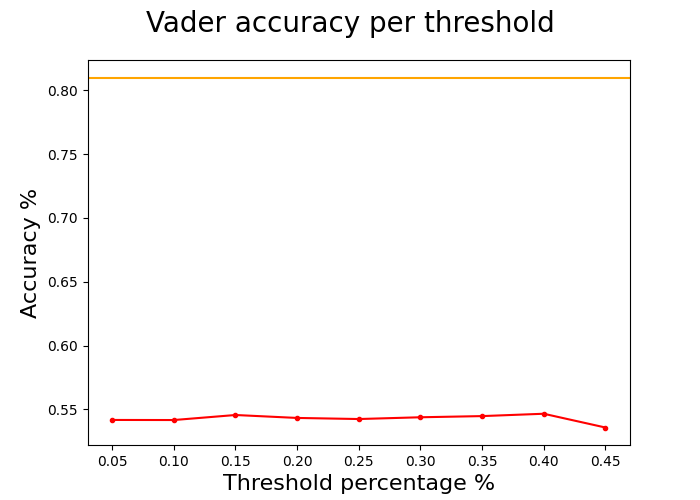

```python
fig = plt.figure()
plt.plot(thresholds, accuracies, 'r.-', label='VADER')
plt.axhline(y=0.81, color='#FFA500', linestyle='-', label='BERT')
fig.suptitle('Vader accuracy per threshold', fontsize=20)
plt.xlabel('Threshold percentage %', fontsize=16)
plt.ylabel('Accuracy %', fontsize=16)
fig.savefig('./shweht_images/graph.png')
```

### 4.2.3 Discussion

This is not to say that BERT is strictly better than VADER. As actual performance within our pipeline is hard to quantify.

# 5 Summary and COVIDTWITTER Recommendations

Overally, we have shown that it is possible to create a contextually aware BERT model in order to classfiy Tweets. The model outperforms VADER in our testing set and in preliminary testing in some instances. I would recommend using the BERT model for sentiment analysis as it is an improvement over the alternative VADER. This model should be used for the existing Twitter Analysis pipeline for sentiment scoring. Additionally, the model should be used for sentiment scoring with the distribution of tweets generated by DialoGPT. However, I would recommend improving the model in the following ways. * Model Improvements While the improvement over VADER is a good first step, the BERT model can still be improved upon. 81% accuracy on the testing set may not be enough. 1. Training Data A model is reliant on the training data that it is built on top of. Since the SemEval Dataset was used, the Dataset only contains tweets from the time period 2013-2017 and model only “learns” the tweets within this context. Therefore, the model doesn’t understand the context behind Tweets made during the covid time. The model has not learned new terms used during COVID times, for example, the model might not understand how the word “COVID” is used in context. To make improvements to the model, more labeled data can be given to training model with Tweets with COVID relavent terms. 2. Updating the Neural Network Architecture The model uses huggingface transformers to create a classification neural net. This package automatically creates a neural net with a basic architecture. This means that the lasy layer goes from 768 to 3 descriptors. Possible improvemnts would include creating a custom neural net with 2 additional convolutional layers and with dropout at each layer. 3. Pretraining the parameters One possible improvement would be to pretrain BERT’s parameters beforing training on the training set. 4. Using a different base model CT-BERT has produced a good baselien for prediction accuracy. Other models could be explored for improved accuracy (RoBERTa, XLM, ect…)

# 6 References

- https://arxiv.org/pdf/2005.07503.pdf Paper on a BERT model trained on tweets during the start of the coronavirus pandemic
- https://arxiv.org/pdf/1704.06125v1.pdf Paper on evaluating sentiment of tweets using CNNs on SemEval dataset
- https://huggingface.co/transformers/custom_datasets.html How to finetune BERT models in PyTorch
- https://medium.com/@aniruddha.choudhury94/part-2-bert-fine-tuning-tutorial-with-pytorch-for-text-classification-on-the-corpus-of-linguistic-18057ce330e1 Example of training BERT for a classification problem
- https://www.dropbox.com/s/byzr8yoda6bua1b/2017_English_final.zip SemEval dataset
- https://curiousily.com/posts/sentiment-analysis-with-bert-and-hugging-face-using-pytorch-and-python/ Blogpost on how to fine tune BERT to predict for a specific language problem
- https://huggingface.co/transformers/custom_datasets.html How to finetune BERT models in PyTorch
- https://mccormickml.com/2019/07/22/BERT-fine-tuning/ Example of how to construct a training loop for Bert
- https://www.dropbox.com/s/byzr8yoda6bua1b/2017_English_final.zip SemEval dataset
- https://github.com/cjhutto/vaderSentiment Vader Sentiment

# 7 Appendix

[figure not shown]

[figure not shown]